# Lab #03: Spatial Data Visualization + Wrangling

due Monday, May 23 at 11:59pm

# Goals

- Wrangle data in a meaningful way using `dplyr` functions.
- Develop effective spatial visualizations to answer research questions.
- Continue developing a workflow for reproducible data analysis.

# Getting started

- Go to [course GitHub organization page](https://github.com/sta199-summer22) and find the repository entitled “lab03-GitHubUsername”
- Clone the repo and make a new project in RStudio.
- Find `lab03.Rmd` to open the template R Markdown file.

All plots should follow best visualization practices; plots should include:

- an informative title,
- axes that are labeled, and
- careful consideration should be given to aesthetic choices.

Don’t forget to label your R chunk as well. Your label should be short, informative, shouldn’t include spaces, and shouldn’t repeat a previous label.

# Packages

We need the **tidyverse** and **dsbox** for this lab. If you don’t have `dsbox` already installed, please run commented lines only *once*.

```r
library(tidyverse)
theme_set(theme_bw())
# install.packages("devtools")
# devtools::install_github("rstudio-education/dsbox")
library(dsbox) # for data
library(sf)
```

# North Carolina Bycycle Crash Data

The data set `ncbikecrash` is available in the `dsbox` package and contains all NC bike crash data from 2007 - 2014. Check the documentation of the data by typing `?ncbikecrash` in your console.

1. Create a line plot displaying temporal changes of the number of bike accidents where the drivers age is between 0 and 19, inclusive, with points at each year. Make each year have a tick and a label on the x-axis. Hint: you may use `geom_line()`, `geom_point()`, and `scale_x_continuous(breaks = 2007:2014)`. Please describe what you observe.

🧶 ✅ ⬆️ Knit, commit, and push your final changes to GitHub with a meaningful commit message.

2. We examine if there is any relationship between `crash_hour` and `hit_run`.
   - Create bar plots of `crash_hour` at each level of `hit_run` using faceting. What do you learn about the relationship from this plot?
   - Create a segmented bar plot displaying proportions of hit and run at different hours. What do you learn about the relationship from this plot?
   - Which plot do you think is more effective? Why?

🧶 ✅ ⬆️ Knit, commit, and push your final changes to GitHub with a meaningful commit message.

3. Recreate the following plot and describe in context of the data. The aesthetic factor alpha is set at 0.85. Colors used are #A04543, #FFFFCC, and #EBA553. Note for this exercise you should begin with the code below. The `ifelse([condition], [value1], [value2])` function assigns `[value1]` if `[condition]` holds and `[value2]` otherwise.

```r
ncbikecrash <- ncbikecrash %>%
  mutate(week = ifelse(crash_day %in% c("Saturday", "Sunday"),
                       "Weekend", "Weekday"))
```

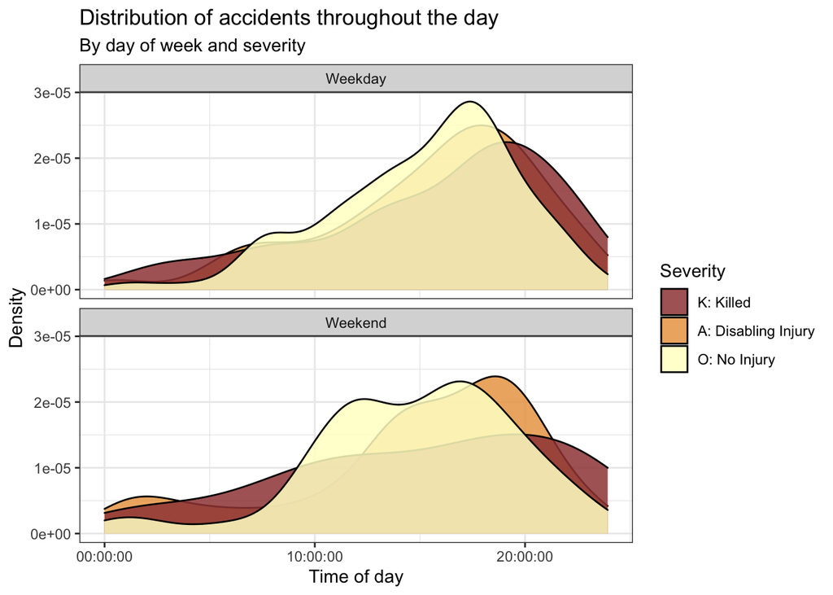

🧶 ✅ ⬆️ Knit, commit, and push your final changes to GitHub with a meaningful commit message.

Now we will play with spatial data. Use the code below to load the NC shapefile downloaded from [NC OneMap](https://www.nconemap.gov/datasets/NCEM-GIS::north-carolina-state-and-county-boundary-polygons/about).

```r
nc_counties <- st_read("data/nc_counties.shp", quiet = TRUE)
```

4. Join `ncbikecrash` and `nc_counties`.
   - What variable can be an identifier joining the two data sets? Please leave only the identifier of your choosing and geometry from `nc_counties`.
   - Create a data set called `ncbikecrash_sf` that contains all accidents in `ncbikecrash` and associated geometry features. The resulting data set should be a simple feature, too.
5. Create an NC map with counties colored according to the total number of accidents between 2007 and 2014. You may use `scale_fill_gradient()` to fill counties with a color gradient. Use informative colors for *low* and *high* number of accidents.
   - What are the counties with the high number ($>$ 750) of accidents?
   - Can you conclude that bikers should avoid those counties based on the above map? Explain your answer. If not, which map would you consider instead to examine which counties are dangerous for bikers?
6. Identify the county that is not drawn on the map above using an appropriate join function.

🧶 ✅ ⬆️ Knit, commit, and push your final changes to GitHub with a meaningful commit message.

# Submission

Once you are fully satisfied with your lab, **Knit to .pdf** to create a PDF document.

Follow the instructions in previous labs to submit your PDF to Gradescope.

Be sure to identify which problems are on each page using Gradescope.

Once you are finished with the lab, you will submit the PDF document produced from your final *knit, commit, and push* to Gradescope.

**Before you wrap up the assignment, make sure all documents are updated on your GitHub repo. We will be checking these to make sure you have been practicing how to commit and push changes.** **Remember – you must turn in a .pdf file to the Gradescope page by the submission deadline to be considered “on time”.**

To submit your assignment:

- Go to http://www.gradescope.com and click *Log in* in the top right corner.
- Click *School Credentials* $\rightarrow$ *Duke NetID* and log in using your NetID credentials.
- Click on your *STA 199* course.
- Click on the assignment, and you’ll be prompted to submit it.
- Mark all the pages associated with exercise. All the pages of your lab should be associated with at least one question (i.e., should be “checked”).
- Select the first page of your .pdf submission to be associated with the *“Workflow & formatting”* question.

# Grading (50 pts)

| Component | Points |
| --- | --- |
| Ex 1 | 7 |
| Ex 2 | 9 |
| Ex 3 | 10 |
| Ex 4 | 6 |
| Ex 5 | 7 |
| Ex 6 | 4 |
| Workflow & formatting | 7 |

**Grading notes**:

- The “Workflow & formatting” grade is to assess the reproducible workflow. This includes updating the name on the assignment to your name, having at least 3 informative commit messages, labeling the code chunks, and having readable code that does not exceed 80 characters (i.e., we can read all your code in the knitted PDF.)